# Chapter 7 Problem Set Solutions

```r
library(ggplot2)
library(readxl)
setwd("C:/Users/timma/Documents/GitHub/FIN6572Fall2020/Problem Sets/Ch7")
```

### 7.1

```r
myData = read_xlsx("Ch7_Q4_Data_File.xlsx")
```

Model 1 (No Interaction):

```r
Model1 <- lm(y ~ x + d1 + d2, data = myData)
summary(Model1)
```

```
Call:
lm(formula = y ~ x + d1 + d2, data = myData)

Residuals:
    Min      1Q  Median      3Q     Max
-14.572  -5.888   1.678   4.188  18.781

Coefficients:
            Estimate Std. Error t value Pr(>|t|)
(Intercept)   11.323      5.753   1.968  0.06662 .
x              1.353      0.389   3.477  0.00311 **
d1            14.024      4.196   3.342  0.00413 **
d2           -11.983      4.080  -2.937  0.00966 **
---
Signif. codes:  0 ‘***’ 0.001 ‘**’ 0.01 ‘*’ 0.05 ‘.’ 0.1 ‘ ’ 1

Residual standard error: 8.804 on 16 degrees of freedom
Multiple R-squared:  0.6205,    Adjusted R-squared:  0.5493
F-statistic:  8.72 on 3 and 16 DF,  p-value: 0.001169
```

Model 2 (Interaction):

```r
Model2 <- lm(y ~ x + d1 + d2 + d1*d2, data = myData)
summary(Model2)
```

```
Call:
lm(formula = y ~ x + d1 + d2 + d1 * d2, data = myData)

Residuals:
    Min      1Q  Median      3Q     Max
-15.150  -5.474   1.036   3.474  18.266

Coefficients:
            Estimate Std. Error t value Pr(>|t|)
(Intercept)  10.0457     6.9220   1.451   0.1673
x             1.4164     0.4384   3.231   0.0056 **
d1           15.7348     6.4623   2.435   0.0279 *
d2          -10.8921     5.1983  -2.095   0.0535 .
d1:d2        -3.3627     9.4556  -0.356   0.7271
---
Signif. codes:  0 ‘***’ 0.001 ‘**’ 0.01 ‘*’ 0.05 ‘.’ 0.1 ‘ ’ 1

Residual standard error: 9.055 on 15 degrees of freedom
Multiple R-squared:  0.6237,    Adjusted R-squared:  0.5233
F-statistic: 6.215 on 4 and 15 DF,  p-value: 0.003723
```

Calculate predicted values from Model 1.

```r
x = 20
d1 = 1
d2 = 0
Model1$coefficients[1] + Model1$coefficients[2]*x + Model1$coefficients[3]*d1 + Model1$coefficients[4]*d2
```

```
(Intercept)
   52.40044
```

```r
d2 = 1
Model1$coefficients[1] + Model1$coefficients[2]*x + Model1$coefficients[3]*d1 + Model1$coefficients[4]*d2
```

```
(Intercept)
     40.417
```

### 7.2

```r
myData = read_xlsx("Ch7_Q9_Data_File.xlsx")
```

a.1 Multiple Linear Regression Model:

```r
Model1 <- lm(Income~ Hours + Hot + Holiday, data = myData)
summary(Model1)
```

```
Call:
lm(formula = Income ~ Hours + Hot + Holiday, data = myData)

Residuals:
    Min      1Q  Median      3Q     Max
-67.334 -22.240  -1.334  26.478  87.358

Coefficients:
            Estimate Std. Error t value Pr(>|t|)
(Intercept)   -1.449     30.762  -0.047 0.962729
Hours         32.023      4.329   7.397  2.5e-08 ***
Hot           90.508     12.659   7.150  4.9e-08 ***
Holiday       54.094     13.091   4.132 0.000253 ***
---
Signif. codes:  0 ‘***’ 0.001 ‘**’ 0.01 ‘*’ 0.05 ‘.’ 0.1 ‘ ’ 1

Residual standard error: 36.79 on 31 degrees of freedom
Multiple R-squared:  0.8094,    Adjusted R-squared:  0.7909
F-statistic: 43.88 on 3 and 31 DF,  p-value: 2.868e-11
```

a.2 Predict scenarios:

```r
hours = 6
hot = 1
holiday = 1
Model1$coefficients[1] + Model1$coefficients[2]*hours + Model1$coefficients[3]*hot + Model1$coefficients[4]*holiday
```

```
(Intercept)
   335.2886
```

```r
holiday = 0
Model1$coefficients[1] + Model1$coefficients[2]*hours + Model1$coefficients[3]*hot + Model1$coefficients[4]*holiday
```

```
(Intercept)
   281.1948
```

b.1 Multiple Linear Regression Model (with Interaction):

```r
Model2 <- lm(Income ~ Hours + Hot + Holiday + Hot*Holiday, data = myData)
summary(Model2)
```

```
Call:
lm(formula = Income ~ Hours + Hot + Holiday + Hot * Holiday,
    data = myData)

Residuals:
    Min      1Q  Median      3Q     Max
-81.776 -21.962  -6.808  21.552  70.998

Coefficients:
            Estimate Std. Error t value Pr(>|t|)
(Intercept)   25.055     30.613   0.818 0.419551
Hours         29.487      4.158   7.092 6.93e-08 ***
Hot           66.860     15.284   4.375 0.000135 ***
Holiday       25.534     16.936   1.508 0.142097
Hot:Holiday   60.434     24.925   2.425 0.021559 *
---
Signif. codes:  0 ‘***’ 0.001 ‘**’ 0.01 ‘*’ 0.05 ‘.’ 0.1 ‘ ’ 1

Residual standard error: 34.2 on 30 degrees of freedom
Multiple R-squared:  0.8406,    Adjusted R-squared:  0.8194
F-statistic: 39.56 on 4 and 30 DF,  p-value: 1.481e-11
```

b.2 Predict scenarios:

```r
hours = 6
hot = 1
holiday = 1
Model2$coefficients[1] + Model2$coefficients[2]*hours + Model2$coefficients[3]*hot + Model2$coefficients[4]*holiday + Model2$coefficients[5]*hot*holiday
```

```
(Intercept)
   354.8029
```

```r
holiday = 0
Model2$coefficients[1] + Model2$coefficients[2]*hours + Model2$coefficients[3]*hot + Model2$coefficients[4]*holiday + Model2$coefficients[5]*hot*holiday
```

```
(Intercept)
   268.8348
```

### 7.3

```r
myData = read_xlsx("Ch7_Q11_Data_File.xlsx")
```

1. Model 1: Linear Regression of Consumption on Income

```r
Model1 <- lm(Consumption ~ Income, data = myData)
summary(Model1)
```

```
Call:
lm(formula = Consumption ~ Income, data = myData)

Residuals:
   Min     1Q Median     3Q    Max
-21780  -6439   1065   5531  20703

Coefficients:
             Estimate Std. Error t value Pr(>|t|)
(Intercept) 8.160e+03  5.650e+03   1.444    0.155
Income      5.485e-01  6.611e-02   8.297 7.85e-11 ***
---
Signif. codes:  0 ‘***’ 0.001 ‘**’ 0.01 ‘*’ 0.05 ‘.’ 0.1 ‘ ’ 1

Residual standard error: 9553 on 48 degrees of freedom
Multiple R-squared:  0.5892,    Adjusted R-squared:  0.5806
F-statistic: 68.85 on 1 and 48 DF,  p-value: 7.853e-11
```

```r
income = 75000
Model1$coefficients[1] + Model1$coefficients[2]*income
```

```
(Intercept)
   49300.29
```

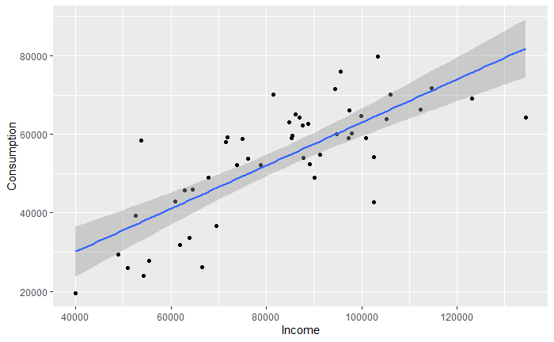

```r
ggplot(myData,aes(y=Consumption,x=Income))+geom_point()+geom_smooth(method="lm")
```

2. Model 2: Include urban dummy (allow for each type of community to have a distinct intercept, but same slope)

```r
Model2 <- lm(Consumption ~ Income + Urban, data = myData)
summary(Model2)
```

```
Call:
lm(formula = Consumption ~ Income + Urban, data = myData)

Residuals:
     Min       1Q   Median       3Q      Max
-16474.5  -6421.2   -916.9   6360.2  21459.8

Coefficients:
             Estimate Std. Error t value Pr(>|t|)
(Intercept) 1.301e+04  6.109e+03   2.129   0.0385 *
Income      4.444e-01  8.577e-02   5.181 4.55e-06 ***
Urban       6.544e+03  3.551e+03   1.843   0.0717 .
---
Signif. codes:  0 ‘***’ 0.001 ‘**’ 0.01 ‘*’ 0.05 ‘.’ 0.1 ‘ ’ 1

Residual standard error: 9323 on 47 degrees of freedom
Multiple R-squared:  0.6169,    Adjusted R-squared:  0.6006
F-statistic: 37.84 on 2 and 47 DF,  p-value: 1.615e-10
```

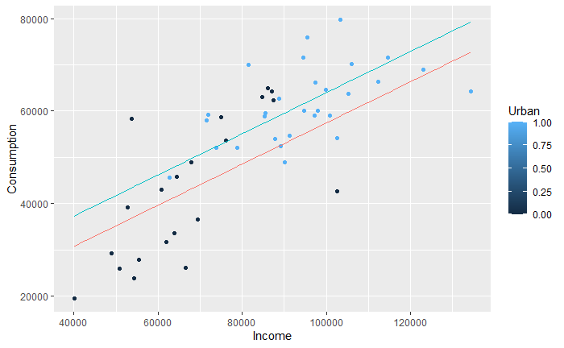

```r
equation1=function(x){coef(Model2)[1]+coef(Model2)[2]*x}
equation2=function(x){coef(Model2)[1]+coef(Model2)[2]*x+coef(Model2)[3]}
ggplot(myData,aes(y=Consumption,x=Income,color=Urban))+geom_point()+
        stat_function(fun=equation1,geom="line",color=scales::hue_pal()(2)[1])+
        stat_function(fun=equation2,geom="line",color=scales::hue_pal()(2)[2])
```

Predict consumption for family with $75k income in urban vs. rural communities.

```r
urban = 1
Model2$coefficients[1] + Model2$coefficients[2]*income + Model2$coefficients[3]*urban
```

```
(Intercept)
   52880.16
```

```r
urban = 0
Model2$coefficients[1] + Model2$coefficients[2]*income + Model2$coefficients[3]*urban
```

```
(Intercept)
   46335.73
```

3. Model 3: Include interaction between urban dummy and income (allow for distinct intercepts and distinct slopes across the two community types)

```r
Model3 <- lm(Consumption ~ Income + Urban + Income*Urban, data = myData)
summary(Model3)
```

```
Call:
lm(formula = Consumption ~ Income + Urban + Income * Urban, data = myData)

Residuals:
     Min       1Q   Median       3Q      Max
-23688.2  -6047.0   -489.5   5227.7  24379.7

Coefficients:
               Estimate Std. Error t value Pr(>|t|)
(Intercept)  -1676.5822  8708.3864  -0.193  0.84818
Income           0.6630     0.1264   5.246 3.83e-06 ***
Urban        36361.7065 13527.3483   2.688  0.00997 **
Income:Urban    -0.3789     0.1664  -2.277  0.02745 *
---
Signif. codes:  0 ‘***’ 0.001 ‘**’ 0.01 ‘*’ 0.05 ‘.’ 0.1 ‘ ’ 1

Residual standard error: 8933 on 46 degrees of freedom
Multiple R-squared:  0.6557,    Adjusted R-squared:  0.6333
F-statistic:  29.2 on 3 and 46 DF,  p-value: 1.006e-10
```

Predict consumption for family with $75k income in urban vs. rural communities using Model 3.

```r
urban = 1
Model3$coefficients[1] + Model3$coefficients[2]*income + Model3$coefficients[3]*urban + Model3$coefficients[4]*income*urban
```

```
(Intercept)
   55995.18
```

```r
urban = 0
Model3$coefficients[1] + Model3$coefficients[2]*income + Model3$coefficients[3]*urban + Model3$coefficients[4]*income*urban
```

```
(Intercept)
   48050.56
```

### 7.4

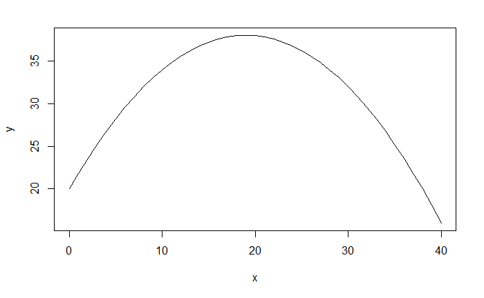

```r
x = 0:40
y = 20 + 1.9*x - 0.05*x^2
plot(x,y,'l')
```

2. The predicted response $\hat{y}$ is maximized when first derivative is equal to 0:

$\dfrac{dy}{dx} = 1.9 - 2*0.05x = 0 \implies x = \dfrac{1.9}{0.1} = 19$

### 7.5

Use each of the model designs to calculate the predicted repsonses.

### 7.6

```r
myData = read_xlsx("Ch7_Q33_Data_File.xlsx")
```

Model 1: Linear Model ($y=X\beta+\epsilon$)

```r
Model1 <- lm(Rent ~ Beds+Baths+Sqft, data = myData)
summary(Model1)
```

```
Call:
lm(formula = Rent ~ Beds + Baths + Sqft, data = myData)

Residuals:
    Min      1Q  Median      3Q     Max
-781.81 -142.34   12.59  220.26  376.59

Coefficients:
            Estimate Std. Error t value Pr(>|t|)
(Intercept)  65.8255   267.2604   0.246    0.808
Beds        237.8506   194.8622   1.221    0.235
Baths       389.3673   103.3422   3.768    0.001 ***
Sqft          0.1831     0.6057   0.302    0.765
---
Signif. codes:  0 ‘***’ 0.001 ‘**’ 0.01 ‘*’ 0.05 ‘.’ 0.1 ‘ ’ 1

Residual standard error: 284.6 on 23 degrees of freedom
Multiple R-squared:  0.7936,    Adjusted R-squared:  0.7667
F-statistic: 29.47 on 3 and 23 DF,  p-value: 4.682e-08
```

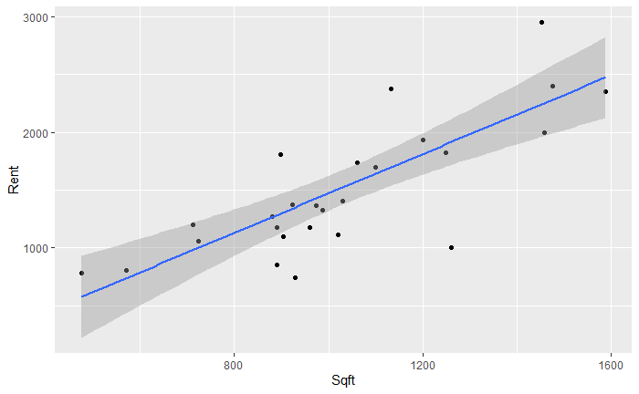

```r
ggplot(myData,aes(y=Rent,x=Sqft))+geom_point()+geom_smooth(method="lm")
```

Model 2: Exponential Model ($\ln(y) = X\beta+\epsilon$)

```r
Model2 <- lm(log(Rent) ~ Beds+Baths+Sqft, data = myData)
summary(Model2)
```

```
Call:
lm(formula = log(Rent) ~ Beds + Baths + Sqft, data = myData)

Residuals:
     Min       1Q   Median       3Q      Max
-0.52567 -0.06619  0.00169  0.14377  0.28289

Coefficients:
             Estimate Std. Error t value Pr(>|t|)
(Intercept) 6.2925286  0.1940735  32.423  < 2e-16 ***
Beds        0.1325781  0.1415008   0.937  0.35852
Baths       0.2190676  0.0750428   2.919  0.00772 **
Sqft        0.0002476  0.0004398   0.563  0.57887
---
Signif. codes:  0 ‘***’ 0.001 ‘**’ 0.01 ‘*’ 0.05 ‘.’ 0.1 ‘ ’ 1

Residual standard error: 0.2067 on 23 degrees of freedom
Multiple R-squared:  0.7408,    Adjusted R-squared:  0.707
F-statistic: 21.91 on 3 and 23 DF,  p-value: 6.232e-07
```

2. Predict rent for a $1,500 sq.ft. house with 3 bed and 2 bath. For the exponential model, we must first calculate the bias correction term ($\sigma^2/2$) and add that before applying the exponential function.

```r
bed = 3
bath = 2
size = 1500
Model1$coefficients[1] + Model1$coefficients[2]*bed + Model1$coefficients[3]*bath + Model1$coefficients[4]*size
```

```
(Intercept)
   1832.753
```

```r
SE<-summary(Model2)$sigma
exp(Model2$coefficients[1] + Model2$coefficients[2]*bed + Model2$coefficients[3]*bath + Model2$coefficients[4]*size + (SE^2/2))
```

```
(Intercept)
   1846.769
```

3. Calculate $R^2$ for Model 2 by calculating fitted values for y and computing the correlation between the predicted and actual y values.

```r
Pred_lny<-predict(Model2)
Pred_y<-exp(Pred_lny+SE^2/2)
cor(myData$Rent, Pred_y)^2
```

```
[1] 0.8101887
```

### 7.7

```r
myData = read_xlsx("Ch7_Q35_Data_File.xlsx")
names(myData)[1] = "TimePerUnit"
names(myData)[2] = "UnitNumber"
```

Model 1: Linear Regression ($y=X*\beta+\epsilon$)

```r
Model1 <- lm(TimePerUnit ~ UnitNumber, data = myData)
summary(Model1)
```

```
Call:
lm(formula = TimePerUnit ~ UnitNumber, data = myData)

Residuals:
    Min      1Q  Median      3Q     Max
-2.1381 -1.3244 -0.5858  0.6681  6.1243

Coefficients:
            Estimate Std. Error t value Pr(>|t|)
(Intercept) 12.43202    0.72357  17.181  < 2e-16 ***
UnitNumber  -0.08542    0.01249  -6.841 1.97e-07 ***
---
Signif. codes:  0 ‘***’ 0.001 ‘**’ 0.01 ‘*’ 0.05 ‘.’ 0.1 ‘ ’ 1

Residual standard error: 1.955 on 28 degrees of freedom
Multiple R-squared:  0.6256,    Adjusted R-squared:  0.6123
F-statistic:  46.8 on 1 and 28 DF,  p-value: 1.968e-07
```

Model 2: Logarithmic Regression ($y=\ln(X)*\beta+\epsilon$)

```r
Model2 <- lm(TimePerUnit ~ log(UnitNumber), data = myData)
summary(Model2)
```

```
Call:
lm(formula = TimePerUnit ~ log(UnitNumber), data = myData)

Residuals:
     Min       1Q   Median       3Q      Max
-1.69571 -0.62035  0.00591  0.52666  2.41782

Coefficients:
                Estimate Std. Error t value Pr(>|t|)
(Intercept)      20.5623     0.6626   31.03   <2e-16 ***
log(UnitNumber)  -3.4050     0.1764  -19.30   <2e-16 ***
---
Signif. codes:  0 ‘***’ 0.001 ‘**’ 0.01 ‘*’ 0.05 ‘.’ 0.1 ‘ ’ 1

Residual standard error: 0.8451 on 28 degrees of freedom
Multiple R-squared:  0.9301,    Adjusted R-squared:  0.9276
F-statistic: 372.4 on 1 and 28 DF,  p-value: < 2.2e-16
```

Plug in unit 50 to the logarithmic model:

```r
u = 50
t = Model2$coefficients[1] + Model2$coefficients[2]*log(u)
t
```

```
(Intercept)
   7.241857
```

### 7.8

```r
myData = read_xlsx("Ch7_Q37_Data_File.xlsx")
```

```r
Model1 <- lm(log(Q) ~ log(L)+log(K), data = myData)
summary(Model1)
```

```
Call:
lm(formula = log(Q) ~ log(L) + log(K), data = myData)

Residuals:
     Min       1Q   Median       3Q      Max
-1.78693 -0.32424  0.07006  0.24920  1.96040

Coefficients:
            Estimate Std. Error t value Pr(>|t|)
(Intercept)  -0.1741     0.1526  -1.141   0.2601
log(L)        0.7089     0.1068   6.639  3.5e-08 ***
log(K)        0.3431     0.1322   2.596   0.0127 *
---
Signif. codes:  0 ‘***’ 0.001 ‘**’ 0.01 ‘*’ 0.05 ‘.’ 0.1 ‘ ’ 1

Residual standard error: 0.6676 on 45 degrees of freedom
Multiple R-squared:  0.8398,    Adjusted R-squared:  0.8327
F-statistic:   118 on 2 and 45 DF,  p-value: < 2.2e-16
```

### 7.9

```r
myData = read_xlsx("Ch7_Q43_Data_File.xlsx")
```

```r
Linear_Model <-lm(y ~ x1+x2, data =myData)
summary(Linear_Model)
```

```
Call:
lm(formula = y ~ x1 + x2, data = myData)

Residuals:
    Min      1Q  Median      3Q     Max
-0.5698 -0.2362 -0.1613  0.3425  0.8163

Coefficients:
            Estimate Std. Error t value Pr(>|t|)
(Intercept)  0.66169    0.32981   2.006   0.0610 .
x1           0.04020    0.01711   2.350   0.0311 *
x2          -0.08199    0.02982  -2.750   0.0137 *
---
Signif. codes:  0 ‘***’ 0.001 ‘**’ 0.01 ‘*’ 0.05 ‘.’ 0.1 ‘ ’ 1

Residual standard error: 0.4062 on 17 degrees of freedom
Multiple R-squared:  0.4332,    Adjusted R-squared:  0.3666
F-statistic: 6.498 on 2 and 17 DF,  p-value: 0.008014
```

```r
x1 = 12
x2 = 8
Linear_Model$coefficients[1]+Linear_Model$coefficients[2]*x1+Linear_Model$coefficients[3]*x2
```

```
(Intercept)
  0.4882133
```

Logistic regression model (aka logit) is designed to fit binary choice variables (dichotomous).

```r
Logistic_Model <- glm(y ~ x1 + x2, family = binomial(link = logit), data = myData)
summary(Logistic_Model)
```

```
Call:
glm(formula = y ~ x1 + x2, family = binomial(link = logit), data = myData)

Deviance Residuals:
    Min       1Q   Median       3Q      Max
-1.7195  -0.5971  -0.2740   0.5978   2.0514

Coefficients:
            Estimate Std. Error z value Pr(>|z|)
(Intercept)   2.1430     2.5051   0.855   0.3923
x1            0.3123     0.1588   1.966   0.0493 *
x2           -0.6869     0.3478  -1.975   0.0483 *
---
Signif. codes:  0 ‘***’ 0.001 ‘**’ 0.01 ‘*’ 0.05 ‘.’ 0.1 ‘ ’ 1

(Dispersion parameter for binomial family taken to be 1)

    Null deviance: 27.526  on 19  degrees of freedom
Residual deviance: 16.026  on 17  degrees of freedom
AIC: 22.026

Number of Fisher Scoring iterations: 6
```

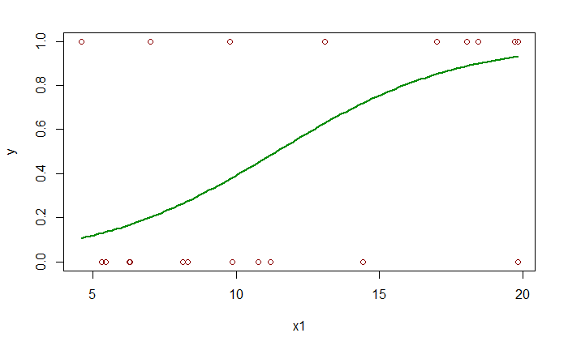

```r
newdat <- data.frame(x1=seq(min(myData$x1), max(myData$x1),len=100))
newdat$x2 = mean(myData$x2)
newdat$y = predict(Logistic_Model, newdata=newdat, type="response")
plot(y~x1, data=myData, col="red4")
lines(y ~ x1, newdat, col="green4", lwd=2)
```

Logistic fitted values:

$\hat{y} = \dfrac{e^{\beta_0+\beta_1x_1+\beta_2x_2}}{1+e^{\beta_0+\beta_1x_1+\beta_2x_2}}$

```r
x1 = 12
x2 = 8
(exp(Logistic_Model$coefficients[1]+Logistic_Model$coefficients[2]*x1+Logistic_Model$coefficients[3]*x2))/(1+exp(Logistic_Model$coefficients[1]+Logistic_Model$coefficients[2]*x1+Logistic_Model$coefficients[3]*x2))
```

```
(Intercept)
  0.5974792
```

### 7.10

```r
myData = read_xlsx("Ch7_Q56_Data_File.xlsx")
```

First, partition the dataset into training (first 30 obs) and testing sets (last 10 obs). Then fit model to training set.

```r
TData <- myData[1:30,]
VData <- myData[31:40,]
Model1 <- lm(y ~ x + d, data = TData)
summary(Model1)
```

```
Call:
lm(formula = y ~ x + d, data = TData)

Residuals:
     Min       1Q   Median       3Q      Max
-20.9364  -5.4061  -0.5485   5.3674  19.9657

Coefficients:
            Estimate Std. Error t value Pr(>|t|)
(Intercept) -11.4232    11.1887  -1.021    0.316
x             4.1121     0.6855   5.999 2.12e-06 ***
d            41.6778     3.7676  11.062 1.56e-11 ***
---
Signif. codes:  0 ‘***’ 0.001 ‘**’ 0.01 ‘*’ 0.05 ‘.’ 0.1 ‘ ’ 1

Residual standard error: 9.414 on 27 degrees of freedom
Multiple R-squared:  0.8449,    Adjusted R-squared:  0.8334
F-statistic: 73.52 on 2 and 27 DF,  p-value: 1.187e-11
```

```r
Model2 <- lm(y ~ x + d + x*d, data = TData)
summary(Model2)
```

```
Call:
lm(formula = y ~ x + d + x * d, data = TData)

Residuals:
     Min       1Q   Median       3Q      Max
-20.8121  -5.8221  -0.2572   5.2217  14.4762

Coefficients:
            Estimate Std. Error t value Pr(>|t|)
(Intercept)   20.827     18.847   1.105   0.2792
x              2.054      1.188   1.729   0.0958 .
d             -3.740     22.264  -0.168   0.8679
x:d            2.928      1.417   2.067   0.0489 *
---
Signif. codes:  0 ‘***’ 0.001 ‘**’ 0.01 ‘*’ 0.05 ‘.’ 0.1 ‘ ’ 1

Residual standard error: 8.89 on 26 degrees of freedom
Multiple R-squared:  0.8668,    Adjusted R-squared:  0.8514
F-statistic: 56.38 on 3 and 26 DF,  p-value: 1.635e-11
```

```r
Pred1 <- predict(Model1, VData)
RMSE1 = sqrt(mean((VData$y-Pred1)^2))
Pred2 <- predict(Model2, VData)
RMSE2 = sqrt(mean((VData$y-Pred2)^2))
RMSE1
```

```
[1] 14.82456
```

```r
RMSE2
```

```
[1] 11.88264
```